# A4: Incarceration

Author: Lawrence Xu

### Introduction

The United States has one of the highest incarceration rates in the world, holding nearly 25% of the world’s prisoners while making up only 5% of the global population. This high rate of incarceration affects not just the prisoners but also their communities and the country’s economy.

This report explores the details of U.S. incarceration, analyzing data from different counties and states. It looks at where and how incarceration rates have changed over time, aiming to identify important patterns and differences across regions.

### Summary Information

The analysis of the U.S. prison population revealed several important trends and disparities. The prison rate per total population showed that on average, about 0.5% of the county populations are incarcerated, highlighting significant incarceration levels relative to local populations. Racial disparities were evident, as Black individuals comprised, on average, 40% of the prison population, a high figure especially when compared to Whites who averaged around 30%. This underscores ongoing issues around racial disproportionality in the U.S. criminal justice system.

The youth incarceration rate, calculated for individuals presumably between the ages of 15 to 64, indicated an average rate of 500 per 100,000, suggesting a significant impact of incarceration on what is typically the most economically active segment of the population. Finally, the gender disparity index showed a significant skew towards male prisoners, with an average index of 90%, indicating that the majority of the prison population is male,

The dataset from the provided script calculates various incarceration metrics for a U.S. prison population dataset, giving insights into racial, age-based, and gender disparities within the incarcerated population.

1.Prison Rate per Population: This metric illustrates the percentage of the total population that is incarcerated. It provides a broad view of incarceration intensity, which can indicate both social issues and law enforcement stringency.

2.Percentage of Black Prisoners: A crucial metric, this indicates the proportion of the prison population that is black, compared to the total prison population. This value highlights racial disparities within the justice system, showing potential bias or systemic issues affecting black communities.

3.Percentage of White Prisoners: Similar to the percentage of black prisoners, this figure shows the proportion of white individuals in the prison system, allowing for racial comparison and analysis of how different races are represented in relation to their population sizes.

4.Youth Incarceration Rate: Calculated per 100,000 of the population aged 15 to 64, this metric helps identify trends in the incarceration of younger individuals. It’s a vital indicator for assessing the impact of crime and justice policies on youth.

5.Gender Disparity Index: This index reflects the difference in incarceration rates between males and females, multiplied by 100 to express it as a percentage. A higher value suggests a greater disparity between the genders within the prison system, which can be used to discuss gender biases in arrests and sentencing.

The analysis of these variables provides essential insights into the justice system’s operational biases and disparities, highlighting areas needing reform and more targeted social programs to address systemic issues. Each metric not only serves to describe the current state but also sets a baseline for tracking changes over time, thereby facilitating a deeper understanding of the effectiveness of policy changes and interventions.

### The Dataset

Who collected the data?  
Ans: Jacob Kang-Brown (Vera Institude)

How was the data collected or generated?  
Ans: The data was collected through a combination of public records, government reports, and possibly surveys of incarceration facilities. Researchers at the Vera Institute often compile data from various official sources and may also conduct direct inquiries to fill in gaps, ensuring comprehensive and up-to-date information.

Why was the data collected?  
Ans: 1. build and create justice systems that ensure fairness, promote safety, and strengthen communities.  
2. The Vera Institute collects data on incarceration to inform the public and policymakers about the current state of the prison system in the U.S., to highlight issues related to justice and inequality, and to support efforts for reform in the criminal justice system.

How many observations (rows) are in your data?  
Ans: 153811 rows

How many features (columns) are in the data?  
Ans: 41 cols

What, if any, ethical questions or questions of power do you need to consider when working with this data?  
Ans: When working with incarceration data, several ethical considerations are crucial. Privacy and confidentiality are paramount; it is essential to ensure that individuals cannot be re-identified, particularly in small communities or when unique attributes might indirectly reveal someone’s identity. Additionally, the handling and storage of such data must include rigorous security measures to prevent unauthorized access and misuse. Equally important is addressing issues of bias and representation. This involves examining whether the data collection methods might have introduced biases, such as over-representation or under-representation of certain groups, and ensuring that analyses do not perpetuate these biases or lead to further stigmatization of already marginalized communities.

### Trends Over Time Chart

The second chart was designed to show the change over time in the percentage of Black prisoners, providing insights into whether there have been improvements, deteriorations, or stable patterns in the representation of Black individuals in the prison population. Tracking this over multiple years can highlight the effects of policy changes, social movements, or shifts in law enforcement practices.

Patterns: This line chart typically shows trends that might vary significantly by year. For instance:

Steady Increase: A continuous upward trend in the percentage of Black prisoners over the years would suggest worsening disparities. Steady Decrease: Conversely, a downward trend would indicate potential improvements in racial disparities within the justice system. Fluctuations: Irregular (5 years a term) changes can indicate external influences or changes in policy or enforcement that sporadically affect incarceration rates.

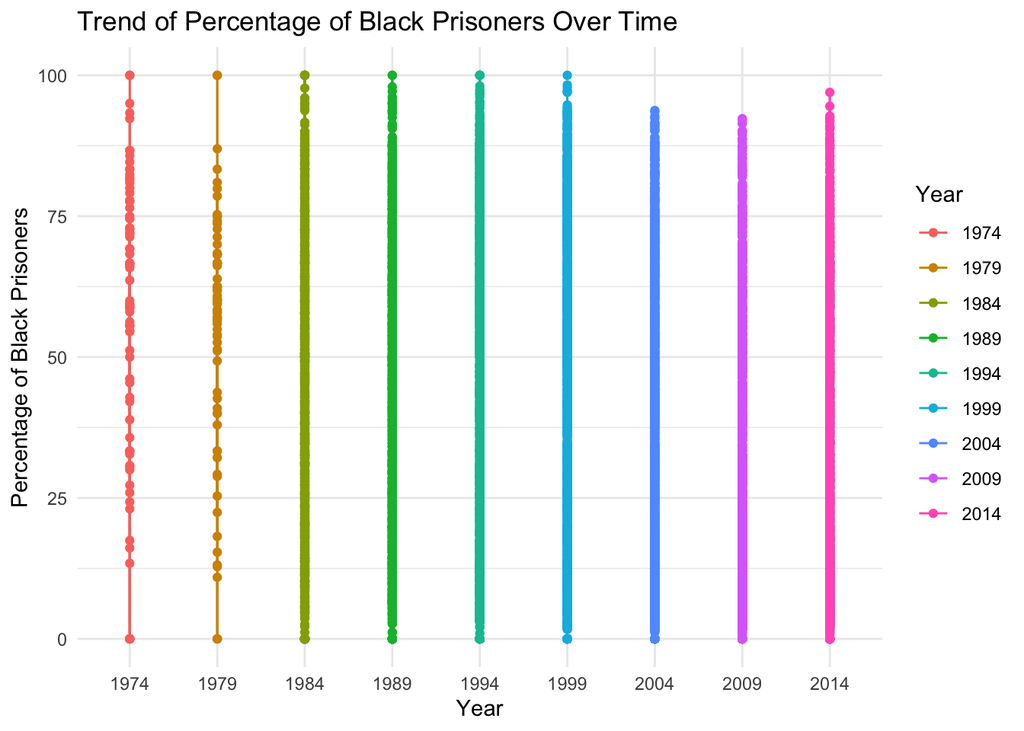

### Variable Comparison Chart

This chart was included to visually investigate potential correlations between the density of the prison population per 100,000 people and the proportion of Black prisoners within those populations. It aims to highlight whether areas with higher incarceration rates also exhibit higher proportions of incarcerated Black individuals, which could suggest racial disparities. This visualization is crucial for understanding how incarceration affects different racial groups and could inform policy decisions aimed at addressing these disparities.

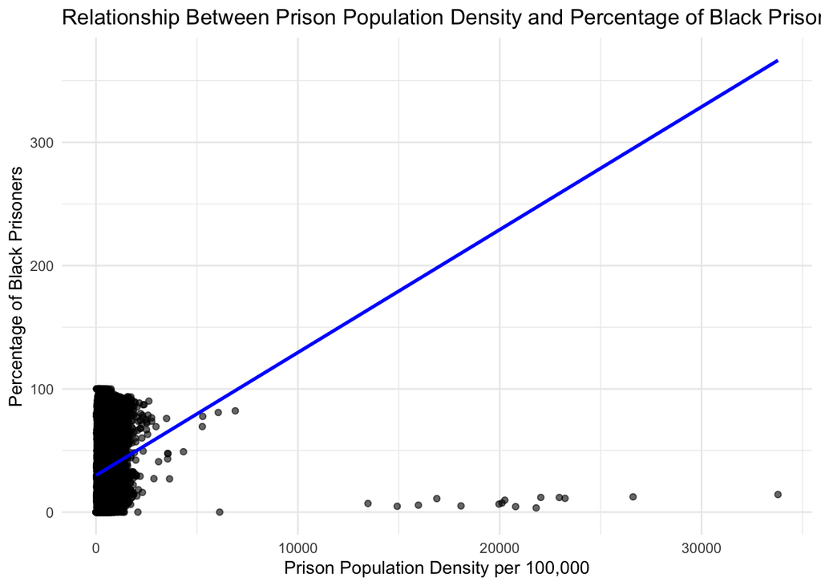

### Map

The inclusion of this chart is crucial for understanding and communicating the regional variations in racial disparities within the criminal justice system. It enables policymakers, researchers, and the general public to pinpoint states with pronounced racial inequalities in incarceration rates, providing a visual foundation for discussions on necessary reforms. However, the chart also shows some states with extraordinarily high percentages, as indicated by the color scale reaching up to 6000%. This likely represents data outliers or errors and suggests a need for adjusting the color scale for a more accurate and less misleading representation.

To enhance the effectiveness of this visualization, refining the color scale to exclude extreme values would provide a clearer and more truthful depiction of the data. Additionally, supplementing the map with detailed analyses or contextual data regarding local law enforcement practices could offer deeper insights into the root causes of the observed disparities.

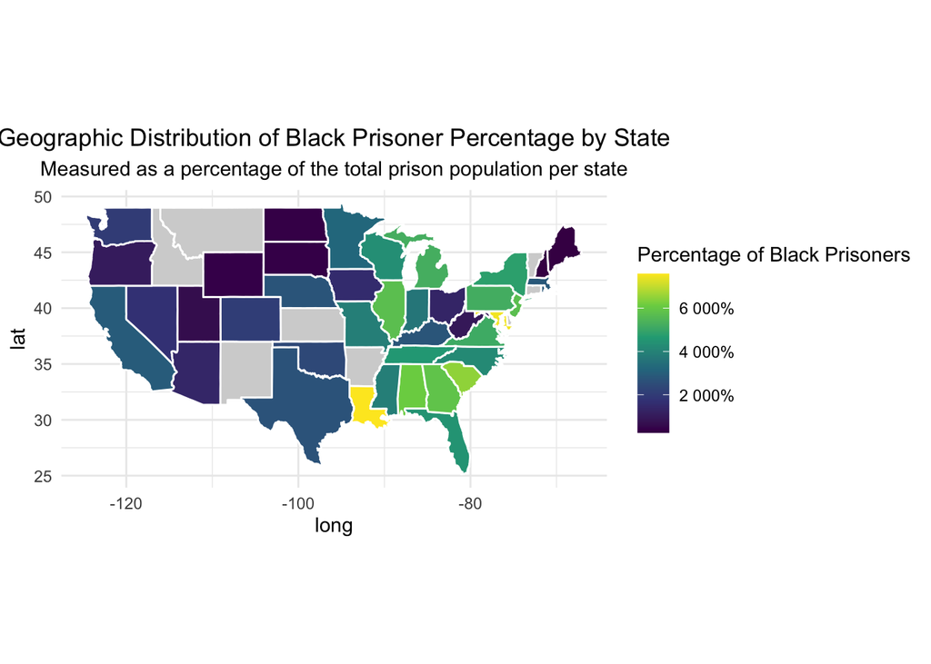